# Installation and setup

1. Requires python 2.7 or above
2. **Best option** is to install using **Anaconda** package, which includes jupyter notebooks
3. `pip` installation

```
python3 -m pip install --upgrade pip
python3 -m pip install jupyter
```

To run jupyter notebooks, from command terminal:

```
$jupyter notebook
```

It will then open your default web browser to localhost URL.

[figure not shown]

Use `Control-C` to stop the server and shut down all kernels. **Keyboard Shortcut To execute a line in jupyter notebook**: `shift` + `Enter`

## Exajupyter

[AIRC wiki link to exajupyter](https://aircwiki.ohsu.edu/ExaJupyter)

Access jupyter notebooks on exacloud from the link: https://exajupyter.ohsu.edu/hub/login

## R on Jupyter notebook

[figure not shown]

# Markdown

**For making a cell as markdown cell**: `Esc` then `m`

**For Headings**: use `#`

**For mathematical symbols and LATEX formatting**: use `$$ <equation> $$` or latex command type \begin{equation*} \end{equation*} or for inline use `$ <equation> $`

## LATEX Example

Einstein's mass-energy relation:

typing this `$$E = m.C^2$$`, gives: $$E = m.C^2$$

The probability of getting (k) heads when flipping (n) coins:

typing this,

```
\begin{equation*}
P(E)   = {n \choose k} p^k (1-p)^{ n-k}
\end{equation*}
```

gives:

\begin{equation*} P(E) = {n \choose k} p^k (1-p)^{ n-k} \end{equation*}

Few more [LATEX examples are in this link](https://jupyter-notebook.readthedocs.io/en/stable/examples/Notebook/Typesetting%20Equations.html).

# Jupyter magic

```python
lsmagic
```

[output not shown]

```python
%system date

# or

!!date
```

```
['Mon Feb 25 12:21:17 PST 2019']
```

**Use bash commands**

```python
ls *.ipynb
```

[output not shown]

```python
%%bash
echo "Hello DCAN"
echo "YES, DCAN!" | sed "s/DCAN/Damien CAN!/"
```

```
Hello DCAN
YES, Damien CAN!!
```

# Python Examples

## Dataframes

```python
import pandas as pd
import numpy as np

# Create Series
s = pd.Series([1, 3, 5, np.nan, 6, 8])
s
```

```
0    1.0
1    3.0
2    5.0
3    NaN
4    6.0
5    8.0
dtype: float64
```

```python
# Date based operations
dates = pd.date_range('20180101', periods=12)
dates
```

```
DatetimeIndex(['2018-01-01', '2018-01-02', '2018-01-03', '2018-01-04',
               '2018-01-05', '2018-01-06', '2018-01-07', '2018-01-08',
               '2018-01-09', '2018-01-10', '2018-01-11', '2018-01-12'],
              dtype='datetime64[ns]', freq='D')
```

Create dataframe and populate the fields with random numbers, and use the dates as index

```python
df = pd.DataFrame(np.random.randn(12, 4), index=dates, columns=list('ABCD'))
df
```

|  | A | B | C | D |
| --- | --- | --- | --- | --- |
| 2018-01-01 | 0.932387 | 0.639445 | -0.532408 | 0.431122 |
| 2018-01-02 | 0.049649 | -1.813135 | -0.348959 | -0.061665 |
| 2018-01-03 | -0.541173 | -0.747849 | -0.252073 | -0.767559 |
| 2018-01-04 | 0.972152 | 0.120042 | -0.776070 | 1.148961 |
| 2018-01-05 | 1.396123 | -2.222199 | 0.829914 | 1.124768 |
| 2018-01-06 | 0.077536 | -2.267171 | 0.206908 | 0.914002 |
| 2018-01-07 | 2.212408 | 0.276697 | 0.459482 | 1.175818 |
| 2018-01-08 | 0.573690 | -0.646303 | 0.247817 | -0.388446 |
| 2018-01-09 | -2.178602 | -2.244739 | -0.001462 | 0.041363 |
| 2018-01-10 | -0.404442 | 0.781142 | 0.035384 | 0.184066 |
| 2018-01-11 | -0.030302 | -0.213607 | 0.186235 | -0.772902 |
| 2018-01-12 | -0.385108 | -0.854706 | -0.318743 | -0.586570 |

```python
# Add another column
df['E'] = pd.Categorical(["test", "train", "test", "train","test", "train", "test", "train","test", "train", "test", "train"])
df
```

|  | A | B | C | D | E |
| --- | --- | --- | --- | --- | --- |
| 2018-01-01 | 0.932387 | 0.639445 | -0.532408 | 0.431122 | test |
| 2018-01-02 | 0.049649 | -1.813135 | -0.348959 | -0.061665 | train |
| 2018-01-03 | -0.541173 | -0.747849 | -0.252073 | -0.767559 | test |
| 2018-01-04 | 0.972152 | 0.120042 | -0.776070 | 1.148961 | train |
| 2018-01-05 | 1.396123 | -2.222199 | 0.829914 | 1.124768 | test |
| 2018-01-06 | 0.077536 | -2.267171 | 0.206908 | 0.914002 | train |
| 2018-01-07 | 2.212408 | 0.276697 | 0.459482 | 1.175818 | test |
| 2018-01-08 | 0.573690 | -0.646303 | 0.247817 | -0.388446 | train |
| 2018-01-09 | -2.178602 | -2.244739 | -0.001462 | 0.041363 | test |
| 2018-01-10 | -0.404442 | 0.781142 | 0.035384 | 0.184066 | train |
| 2018-01-11 | -0.030302 | -0.213607 | 0.186235 | -0.772902 | test |
| 2018-01-12 | -0.385108 | -0.854706 | -0.318743 | -0.586570 | train |

```python
df.columns
```

```
Index(['A', 'B', 'C', 'D', 'E'], dtype='object')
```

```python
df.describe()
```

|  | A | B | C | D |
| --- | --- | --- | --- | --- |
| count | 12.000000 | 12.000000 | 12.000000 | 12.000000 |
| mean | 0.222860 | -0.766032 | -0.021998 | 0.203580 |
| std | 1.118112 | 1.137224 | 0.447913 | 0.751517 |
| min | -2.178602 | -2.267171 | -0.776070 | -0.772902 |
| 25% | -0.389942 | -1.915401 | -0.326297 | -0.437977 |
| 50% | 0.063592 | -0.697076 | 0.016961 | 0.112714 |
| 75% | 0.942328 | 0.159206 | 0.217135 | 0.966693 |
| max | 2.212408 | 0.781142 | 0.829914 | 1.175818 |

Filter based on a categorical value

```python
df[df.E == "test"]
```

|  | A | B | C | D | E |
| --- | --- | --- | --- | --- | --- |
| 2018-01-01 | 0.932387 | 0.639445 | -0.532408 | 0.431122 | test |
| 2018-01-03 | -0.541173 | -0.747849 | -0.252073 | -0.767559 | test |
| 2018-01-05 | 1.396123 | -2.222199 | 0.829914 | 1.124768 | test |
| 2018-01-07 | 2.212408 | 0.276697 | 0.459482 | 1.175818 | test |
| 2018-01-09 | -2.178602 | -2.244739 | -0.001462 | 0.041363 | test |
| 2018-01-11 | -0.030302 | -0.213607 | 0.186235 | -0.772902 | test |

Importing files using pandas as dataframes

```python
df2 = pd.read_excel('/Users/ragotham/Documents/Projects/Juplotter/Example_input_data.xlsx', sheet_name='Sheet1')
df2.head()
```

|  | SubjID | Dx | Dx_name | Sex | Timepoint | M1 | M2 | M3 | M4 | M5 | M6 | M7 | M8 | M9 |
| --- | --- | --- | --- | --- | --- | --- | --- | --- | --- | --- | --- | --- | --- | --- |
| 0 | 1 | 2 | A | M | Baseline | -21.327014 | -28.571429 | 17.670886 | -70.841565 | -9.987820 | 79.856115 | 10.0 | 34.0 | 0.000000 |
| 1 | 2 | 2 | A | M | Baseline | -11.666667 | 0.854701 | 5.818895 | 26.084142 | -21.055950 | 27.272727 | 21.0 | 18.0 | -26.890756 |
| 2 | 3 | 2 | A | M | Baseline | -49.528302 | -34.222222 | 35.342186 | -38.639532 | -33.722238 | 13.851992 | 54.0 | 52.0 | -1.920439 |
| 3 | 4 | 2 | A | M | Baseline | -27.857143 | -18.243243 | 20.067021 | -81.879195 | -20.250723 | -16.718750 | 19.0 | 16.0 | 5.263158 |
| 4 | 5 | 2 | A | M | Baseline | -7.947020 | -3.286385 | 13.626056 | 16.984559 | NaN | NaN | NaN | NaN | NaN |

# Plots

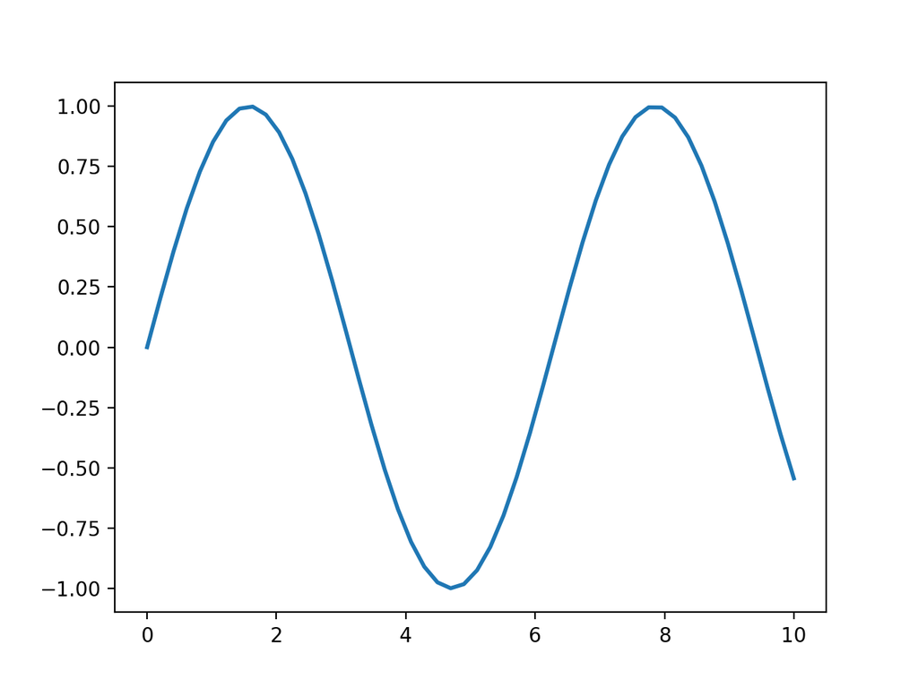

```python
%matplotlib notebook
import matplotlib.pyplot as plt
import numpy as np

x = np.linspace(0,10)
line, = plt.plot(x, np.sin(x),'-', linewidth = 2)
```

# Jupyter notebook as slides

[Presenting code using Jupyter notebook](https://medium.com/@mjspeck/presenting-code-using-jupyter-notebook-slides-a8a3c3b59d67)

- View → Cell Toolbar → Slideshow
- Select the type of slide (Slide, subslide, fragment, notes, etc)
- To run the notebook as slide:

```
jupyter nbconvert <notebook_name>.ipynb --to slides --post serve
```

- To view all the slides in slide mode: press `esc`